# Contents

1. Scale-free property
2. The Barabási-Albert model

```python
import networkx as nx
import numpy as np
import matplotlib as mpl
import matplotlib.pyplot as plt

(__import__('platform').python_version(),
 nx.__version__, np.__version__, mpl.__version__)
```

```
('3.13.7', '3.5', '2.3.3', '3.10.6')
```

Real networks possess three characteristic properties, viz.

- a scale-free degree distribution $P_k\sim k^{-\gamma}$,
- a high average clustering coefficient $C$, and
- a short average shortest path length $L$.

Random networks like the Erdős-Rényi network and small-world networks like the Watts-Strogatz network produce some bell-shaped degree distribution instead of a scale-free one. If we do not use the configuration model to explicitly specify a network's degree sequence, how can we capture the first feature?

More importantly, what does a **scale-free** degree distribution mean and imply?

# 1. Scale-free property

```python
physics = nx.read_gml('datasets/cond-mat.gml')
physics.remove_nodes_from(list(nx.isolates(physics)))

N = physics.number_of_nodes()
E = physics.number_of_edges()
print('number of nodes:', N)
print('number of edges:', E)
print('connectedness  :', nx.is_connected(physics))
```

```
number of nodes: 16264
number of edges: 47594
connectedness  : False
```

A scale-free degree distribution $P_k$ roughly follows a power law $P_k\sim k^{-\gamma}$ for some **degree exponent** $\gamma>0$. Hence, $P_k$ has a very high value for a small $k$ and, theoretically, only vanishes as $k\rightarrow\infty$. This means in that most nodes in a network have a small degree, whereas a few outliers have exceptionally high degrees and act as hubs that connect almost all nodes.

This form of distribution is called "scale-free" for two reasons. Here is the the simpler reason first:

a scale-free distribution looks self-similar when you zoom into a particular part.

\begin{aligned} P_{ak} \sim \left(ak\right)^{-\gamma} \sim k^{-\gamma} \sim P_k \end{aligned}

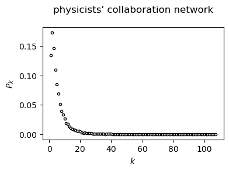

```
minimum degree: 1
maximum degree: 107
```

```python
degs = np.array([k for n, k in physics.degree])
P = np.array(nx.degree_histogram(physics)[min(degs):])/N
kDis = np.arange(min(degs), max(degs)+1)  # DIScrete
kCon = np.logspace(np.log10(kDis[0]),
                   np.log10(kDis[-1]))    # CONtinuous

plt.figure(figsize=(4, 2.5))
plt.plot(kDis, P, 'k.', mfc='w')
plt.title('physicists\' collaboration network\n')
plt.xlabel('$k$')
plt.ylabel('$P_k$')
plt.show()

print('minimum degree:', kDis[0])
print('maximum degree:', kDis[-1])
```

## 1.1 Visualization

As you have learnt, it looks nicer to plot a power law on a logarithmic scale than on a linear scale. At the same time, we should logartihmically bin $P_k$ on a log-log plot, otherwise it overemphasizes the importance of small-degree nodes because a unit interval of the linear scale (i.e. $\Delta k=1$) is stretched on the left end of a log-log plot.

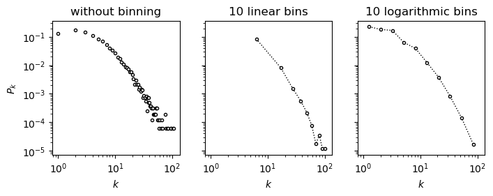

```python
fig, ax = plt.subplots(1, 3, sharex=True, sharey=True, figsize=(8, 2.5))

ax[0].loglog(kDis[P>0], P[P>0], 'k.', mfc='w')
ax[0].set_title('without binning')

pLin, bLin = np.histogram(degs, density=True)
ax[1].loglog((bLin[:-1]+bLin[1:])/2, pLin, 'k.:', mfc='w', lw=1)
ax[1].set_title('10 linear bins')

bLog = np.logspace(*np.log10([kDis[0], kDis[-1]]), 11)
pLog = np.histogram(degs, bLog, density=True)[0]
ax[2].loglog((bLog[:-1]*bLog[1:])**.5, pLog, 'k.:', mfc='w', lw=1)
ax[2].set_title('10 logarithmic bins')

for a in ax: a.set_xlabel('$k$')
ax[0].set_ylabel('$P_k$')
plt.show()
```

We also discussed in Tutorial 4 that we may alternatively plot a degree distribution's **complementary cumulative distribution (cCDF)** $\overline{C}_k$ because it is smoother and does not have zeros. Furthermore, it also follows a power law if $P_k$ follows a power law.

\begin{aligned} \overline{C}_ k = \sum_{k+1}^\infty P_k &\approx \int_{k}^\infty P{\left(k\right)}\,\mathrm{d}k \quad \left(\text{assume $k$ is continuous}\right) \\ &\sim \int_{k}^\infty k^{-\gamma}\,\mathrm{d}k \\ &\sim \vphantom{\int_k^\infty} k^{-\gamma+1} \end{aligned}

Hereafter the notation $P{\left(k\right)}$ explicitly assumes $k$ is continuous, whereas $P_k$ assumes $k$ is discrete. You may wonder why it makes sense to model $k$ as a continuous variable. In fact, when we assume $k$ is continuous, we regard $k$ as a node's **expected degree**, which is averaged over a large number of networks and thus behaves like a real number.

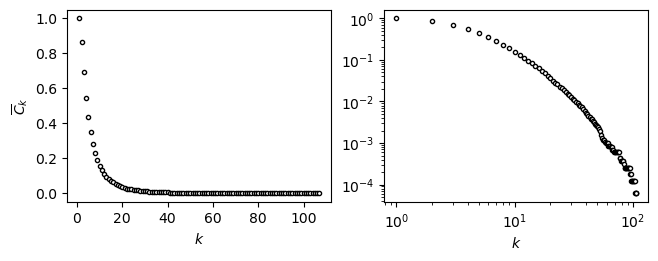

```python
C = np.cumsum(P[::-1])[::-1]

fig, ax = plt.subplots(1, 2, figsize=(7.5, 2.5))
ax[0].plot(kDis, C, 'k.', mfc='w')
ax[1].loglog(kDis, C, 'k.', mfc='w')
ax[0].set_ylabel('$\overline{C}_k$')
for a in ax: a.set_xlabel('$k$')
```

## 1.2 Degree exponent

The most direct way to estimate the degree exponent $\gamma$ is to plot $P_k$ on a logarithmic scale and then to fit it with a straight line, whose slope amounts to $-\gamma$.

\begin{aligned} \ln {P_k} \sim -\gamma \ln {k} \end{aligned}

However, a real degree distribution does not follow a power law perfectly, so its corresponding log-log plot deviates much from a straight line. The deviation is especially significant at extreme $k$, and it is summarized as two phenomena.

- **Low-degree saturation.** A power law diverges as $k\rightarrow0$, so it predicts an infinite amount of low-degree nodes, but this is impossible for a finite network.
- **High-degree cutoff.** A power law does not vanish unless $k\rightarrow\infty$, so it predicts the existence of a node with an arbitrarily high degree. This is also impossible as a finite network definitely has a maximum degree.

As a result, real networks cotain much fewer low-degree and high-degree nodes than predicted, and the method of fitting suffers huge bias depending on which part of $P_k$ we choose to fit.

Worse still, the estimates of $\gamma$ inferred from $\overline{C}_k$ could be quite different from those inferred from $P_k$. The alternative choice of distribution unfortunately makes our measurement even more subjective.

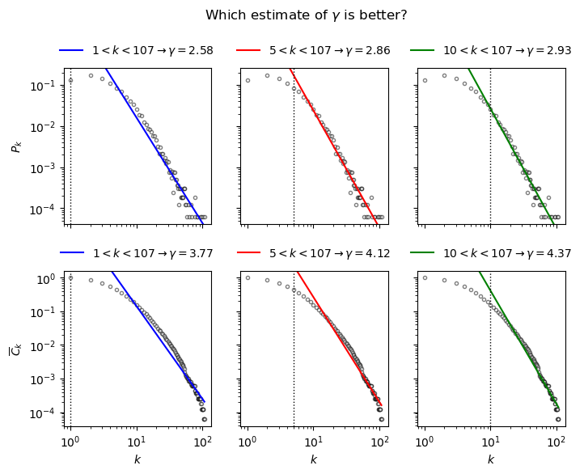

```python
fig, ax = plt.subplots(2, 3, sharex=True, sharey='row',
                       figsize=(8, 2.5*(2+.3)))
plt.subplots_adjust(hspace=.3)

for i, F in enumerate([P, C]):
    for j, lower in enumerate([1, 5, 10]):
        upper = kDis[-1]
        rule = (lower<kDis) * (kDis<upper) * (F>0)
        m, c = np.polyfit(np.log(kDis[rule]), np.log(F[rule]), 1)

        ax[i, j].loglog(kDis[F>0], F[F>0], 'k.', mfc='w', alpha=.5)
        if j==0: ylim = ax[i, j].set_ylim()
        ax[i, j].plot(kCon, np.exp(c)*kCon**m, '-'+['b', 'r', 'g'][j],
                   label=r'$%d<k<%d\rightarrow\gamma=%.3g$'%(lower, upper, -m+i))
        ax[i, j].set_ylim(*ylim)

        ax[i, j].axvline(lower, c='k', ls=':', lw=1)
        ax[i, j].legend(loc='lower center', bbox_to_anchor=(.5, 1), frameon=False)

for a in ax[1]: a.set_xlabel('$k$')
ax[0, 0].set_ylabel('$P_k$')
ax[1, 0].set_ylabel('$\overline{C}_k$')
fig.suptitle('Which estimate of $\gamma$ is better?', y=1.01)
plt.show()
```

### Maximum likelihood estimation.

Another method of estimation resorts to maximum likelihood estimation (MLE). If $N$ points $\left\{x\right\}$ follow a power law $x^{-\alpha}$, [Clauset et al. (2009)](https://epubs.siam.org/doi/abs/10.1137/070710111) suggests that it is most likely for $\alpha $ to be

\begin{aligned} \alpha = 1 + N \left(\sum_{i=1}^N{\ln{\dfrac{x_i}{\min{\left\{x\right\}}-\frac{1}{2}}}}\right)^{-1}\,. \end{aligned}

On the contrary, the derivation of this formula assumes that the points $\left\{x\right\}$ follow a power law perfectly, which is hardly a valid assumption for the degrees $\left\{k\right\}$, so we still need to select the part of $\left\{k\right\}$ that indeed follows a power law. But unlike fitting, we can select this part rather objectively according to some **tedious** statistical techniques. You may check [Barabási's Chapter 4 (2016)](http://networksciencebook.com/chapter/4#advanced-c) if you are interested.

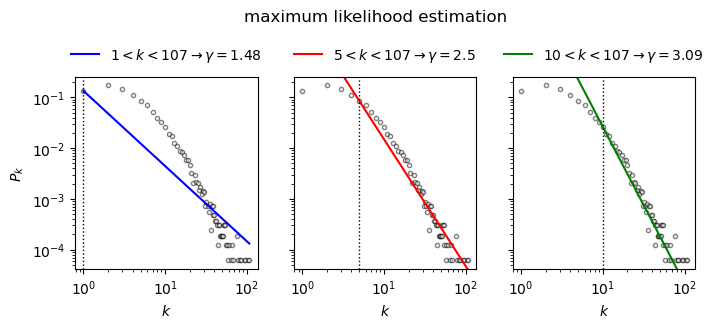

```python
fig, ax = plt.subplots(1, 3, sharex=True, sharey=True, figsize=(8, 2.5))
for i, lower in enumerate([1, 5, 10]):
    upper = kDis[-1]

    g = 1 + 1/np.mean(np.log(degs[lower<=degs]/(lower-.5)))
    Pmle = kDis**-g
    Pmle = Pmle / Pmle[lower-1] * P[lower-1]

    ax[i].loglog(kDis[P>0], P[P>0], 'k.', mfc='w', alpha=.5)
    if i==0: ylim = ax[i].set_ylim()
    ax[i].loglog(kDis, Pmle, '-'+['b', 'r', 'g'][i],
                 label=r'$%d<k<%d\rightarrow\gamma=%.3g$'%(lower, upper, g))
    ax[i].set_ylim(*ylim)

    ax[i].axvline(lower, c='k', ls=':', lw=1)
    ax[i].legend(loc='lower center', bbox_to_anchor=(.5, 1), frameon=False)

for a in ax: a.set_xlabel('$k$')
ax[0].set_ylabel('$P_k$')
fig.suptitle('maximum likelihood estimation', y=1.15)
plt.show()
```

## 1.3 Properties

Now we will see how the degree exponent $\gamma$ critically determines a scale-free network's properties.

### Range of degree.

Although $k^{-\gamma}$ only vanishes at $k\rightarrow\infty$, a real network definitely has a maximum degree $k_\text{max}$, and we wish to compute its expected value given $P_k$. On average, we would like to allow at most one node with $k>k_\text{max}$, so we need to solve

\begin{aligned} N \int_{k_\text{max}}^\infty P{\left(k\right)}\,\mathrm{d}k = 1\,. \end{aligned}

After some algebra, we can find that the expected maximum degree depends on the minimum degree $k_\text{min}$.

\begin{aligned} k_\text{max} = k_\text{min} \, N ^ {\frac{1}{\gamma-1}} \end{aligned}

### Divergence of moments.

The $n$-th moment $\langle{k^n\rangle}$ of a scale-free degree distribution integrates in principle from $k=0$ to $k\rightarrow\infty$, but practically, we trim the range down to $k\in\left[k_\text{min}, k_\text{max}\right]$ to avoid the improper integral.

\begin{aligned} \langle{k^n\rangle} &\equiv \int_0^\infty k^n P{\left(k\right)}\,\mathrm{d}k \\ &\approx \int_{k_\text{min}}^{k_\text{max}} k^{n-\gamma}\,\mathrm{d}k \\ &\sim \dfrac{k_\text{max}^{n-\gamma+1}-k_\text{min}^{n-\gamma+1}}{n-\gamma+1} \end{aligned}

Obviously, $\langle{k^n\rangle}$ diverges because of the denominator when $n=\gamma-1$. Even if $n>\gamma-1$, the nominator blows off because $\dfrac{n}{\gamma-1}-1>0$ and $N\gg 1$.

\begin{aligned} &\,k_\text{max}^{n-\gamma+1} - k_\text{min}^{n-\gamma+1} \\ = &\,k_\text{min}^{n-\gamma+1} N ^ \frac{n-\gamma+1}{\gamma-1} - k_\text{min}^{n-\gamma+1} \\ = &\,k_\text{min}^{n-\gamma+1} \left(N^{\frac{n}{\gamma-1}-1}-1\right) \\ \rightarrow &\infty \end{aligned}

This leads to the deeper meaning of "scale-free":

a scale-free distribution lacks well-behaved moments.

What does such divergence imply? As explained below, a scale-free network tends to have $\gamma\in\left[2, 3\right]$ and thus a diverging second moment $\langle{k^2\rangle}$. It means that while you can reasonably guess an arbitrary node from the network has degree around $\langle{k\rangle}$, you can hardly assess the accuracy of the guess because the network has an infinite variance of degree, i.e. $\langle{k^2\rangle}-\langle{k\rangle}^2\rightarrow\infty$. This class of networks are hence named:

a scale-free network is free of a scale of degree.

### Phase transition.

Furthermore, the size of $\gamma$ divides scale-free networks into three regimes.

1. **Anomalous regime: $\gamma<2$.** Because $k_\text{max}\sim N^\frac{1}{\gamma-1}$ grows faster than $N$, corresponding degree distributions cannot produce graphical degree sequences.
2. **Scale-free regime: $2<\gamma<3$.** Scale-free networks with $\gamma\in\left(2,3\right)$ possess $L\sim\ln{\ln{N}}$, which increases even slower than $\ln{N}$, so scale-free networks are sometimes called **ultra-small-world** networks.
3. **Random regime: $\gamma>3$.** Once $\gamma$ breaks above $3$, the small-world property $L\sim\ln{N}$ re-emerges, and the probability of an exceptionally high-degree node drops so quickly that the resultant networks almost have no hubs, so scale-free networks with $\gamma>3$ simply look random.

The three regimes give two critical points, viz. $\gamma=2$ and $\gamma=3$.

- At $\gamma=2$, $k_\text{max} \sim N$, and it only holds for star-like networks; consequently, $L$ is a constant.
- At $\gamma=3$, a scale-free network possesses $L\sim\dfrac{\ln{N}}{\ln{\ln{N}}}$ and is undergoing a phase transition: the world is both small and ultra-small.

## 1.4 Beyond power laws

Finally, let us have a detour into statistics. As Tutorial 4 points out, "power law" is just a generic term, and we need to be more specific when we describe a distribution.

- If we emphasize that a node has an integer degree, we need the **Zipf distribution**.

\begin{aligned} P_k = \dfrac{k^{-\gamma}}{\sum_{k=k_\text{min}}^\infty k^{-\gamma}} \end{aligned}

- Sometimes we may simplify algebra by considering a node's expected degree, which is a real number, and thus obtain the **Pareto distribution**.

\begin{aligned} P{\left(k\right)} = \dfrac{\gamma-1}{k_\text{min}}\left(\dfrac{k}{k_\text{min}}\right)^{-\gamma} \end{aligned}

Since real networks do not follow these pure power laws perfectly, various complicated distributions may be used for actual fitting, while the following form is the most common choice.

\begin{aligned} P{\left(k\right)} \sim \left(k-k_\text{sat}\right)^{-\gamma}\exp{\left(-\dfrac{k}{k_\text{cut}}\right)} \end{aligned}

The two parameters $k_\text{sat}$ and $k_\text{cut}$ (greater than $k_\text{sat}$) control the extent of low-degree *SAT*uration and high-degree *CUT*off, so the distribution deviates much from a power law at $k<k_\text{sat}$ or $k>k_\text{cut}$. In other words, the distribution fairly resembles a power law at $k\in\left[k_\text{sat}, k_\text{cut}\right]$.

Again, [Barabási's Chapter 4 (2016)](http://networksciencebook.com/chapter/4#advanced-c) provides a thorough discussion on the procedure of fitting. I encourage you to read it if you really want to fit a real degree distribution accurately.

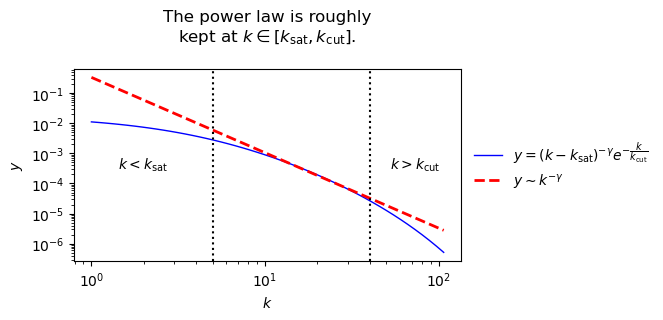

```python
g, kSat, kCut = 2.5, 5, 40
Pfit = (kCon+kSat)**-g * np.exp(kCon/-kCut)

pLaw = kCon**-g
i = np.argmin(np.abs(kCon-(kSat*kCut)**.5))
pLaw = pLaw/pLaw[i]*Pfit[i]

plt.figure(figsize=(5, 2.5))
plt.loglog(kCon, Pfit, 'b-', lw=1,
           label=r'$y=(k-k_\mathrm{sat})^{-\gamma}e^{-\dfrac{k}{k_\mathrm{cut}}}$')
plt.loglog(kCon, pLaw, 'r--', lw=2,
           label=r'$y\sim k^{-\gamma}$')
plt.legend(loc='center left', bbox_to_anchor=(1, .5), frameon=False)
plt.axvline(kSat, c='k', ls=':')
plt.axvline(kCut, c='k', ls=':')

xlim, ylim = plt.xlim(), plt.ylim()
ymid = (ylim[0]*ylim[1])**.5
plt.text((xlim[0]*kSat)**.5, ymid, '$k<k_\mathrm{sat}$', ha='center', va='center')
plt.text((xlim[1]*kCut)**.5, ymid, '$k>k_\mathrm{cut}$', ha='center', va='center')
plt.title('The power law is roughly\nkept at $k\in[k_\mathrm{sat}, k_\mathrm{cut}]$.\n')
plt.xlabel('$k$')
plt.ylabel('$y$')
plt.show()
```

# 2. The Barabási-Albert model

In 1999, [Barabási and Albert](https://www.science.org/doi/10.1126/science.286.5439.509) coined the term "scale-free" to describe degree distributions of real networks and used the Barabási-Albert (BA) model to systemically explain the power-law nature of the distributions. Their paper and Watts and Strogatz's paper on small-world networks in 1998 jointly opened up a, literally, new millennium for network science.

## 2.1 Algorithm

Given an arbitrary graph $G^{\left(0\right)}$ with $m_0$ non-isolated nodes, the model iteratively adds nodes to the graph until it contains $N$ nodes. Every newly added node $i$ is connected to $m$ of the existing nodes $j$, and the probability $p_{ij}$ of connecting $i$ to $j$ depends on the latter's degree $k_j$ before adding $i$.

\begin{aligned} p_{ij} = \dfrac{k_j}{\sum_h k_h} \end{aligned}

Barabási and Albert termed this mechanism "**preferential attachment**" because it is more likely for the new node to join a high-degree node than to join a low-degree node.

At time $t$, the network $G^{\left(t\right)}$ has $t$ nodes and $mt$ edges more than the initial configuration $G^{\left(0\right)}$. The choice of $G^{\left(0\right)}$ is insignificant if $N\gg m_0$, while NetworkX's method `barabasi_albert_graph` defines $G^{\left(0\right)}$ to be an $m$-node star network. Note that the method always generates a simple BA network.

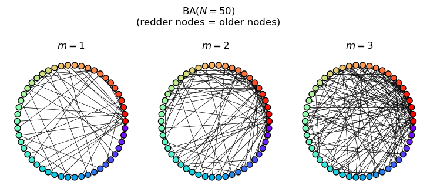

```python
ba = nx.barabasi_albert_graph

N = 50
fig, ax = plt.subplots(1, 3, figsize=(9.2, 3))
plt.subplots_adjust(wspace=.1)
fig.suptitle(r'$\mathrm{BA}\left(N=%d\right)$'%N +
             '\n(redder nodes = older nodes)', y=1.15)
for m in [1, 2, 3]:
    ax[m-1].set_title('$m=%d$' % m)
    nx.draw_circular(ba(N, m, 5056), ax=ax[m-1], width=.5,
                     node_size=50, edgecolors='k',
                     node_color=range(N), vmin=m-1, cmap='rainbow_r')
```

### Linearized chord diagram.

Barabási and Albert in fact defined their model loosely. Not only did they not specify $G^{\left(0\right)}$ but also they did not discuss the possibility of self-loops and multi-edges. Such a loose definition hinders us from calculating the model's properties exactly, so [Bollobás et al. (2001)](https://onlinelibrary.wiley.com/doi/abs/10.1002/rsa.1009) refined Barabási and Albert's definition and created the **linearized chord diagram** (LCD) model. Precisely speaking, the LCD model is not a new model but just a possible form of the BA model.

It starts from a null graph $G^{\left(0\right)}$ (i.e. nothing). Then at step $t$, it inserts one node called $t$ and connects it with $m$ other existing nodes $u$ according to probability

\begin{aligned} p_{tu} = \dfrac{k_u + \delta_{tu}}{\sum_{s=1}^t {k_s} + 1} \,, \end{aligned}

where $k$ is a node's degree before adding the new edges $\left(t,u\right)$. While it keeps Barabási and Albert's idea intact, the LCD model is statistically more tractable because it allows the existence of self-loops and multiedges. Remember that $k=0$ initially and each self-loop increases it by $2$.

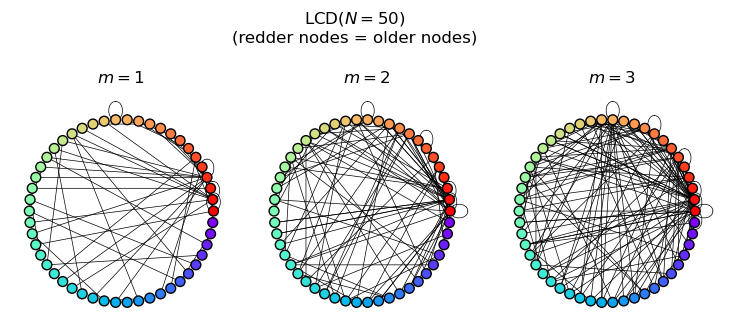

```python
def lcd(N, m, seed=None, record=False):
    np.random.seed(seed)
    G = nx.MultiGraph()
    k = np.zeros((N, N), dtype=float)
    # k[t, i] = node i's degree at step t
    for t in range(N):
        k[t, :t] = [ku for u, ku in G.degree]
        k[t,  t] = 1 # delta_tu
        for edge in range(m):
            p = k[t]/np.sum(k[t]) # p_tu
            u = np.random.choice(N, 1, p=p)[0]
            G.add_edge(t, u)
            k[t, t] += 1; k[t, u] += 1
    return (G, k-np.eye(N, dtype=float)) if record else G

fig, ax = plt.subplots(1, 3, figsize=(9.2, 3))
plt.subplots_adjust(wspace=.1)
fig.suptitle(r'$\mathrm{LCD}\left(N=%d\right)$'%N +
             '\n(redder nodes = older nodes)', y=1.15)
for m in [1, 2, 3]:
    ax[m-1].set_title('$m=%d$' % m)
    nx.draw_circular(lcd(N, m, 5056), ax=ax[m-1], width=.5,
                     node_size=50, edgecolors='k',
                     node_color=range(N), cmap='rainbow_r')
```

## 2.2 Properties

### Degree distribution.

A Barabási-Albert network roughly follows a scale-free degree distribution

\begin{aligned} P_k \approx 2 m^2 k^{-3}\,. \end{aligned}

It is not exact because its derivation assumes $k$ is continuous. Another important reason is the uncertain topology of its initial configuration $G^\left(0\right)$. If the LCD model is used, $P_k$ can be solved exactly.

\begin{aligned} P_k = \dfrac{2m\left(m-1\right)}{k\left(k-1\right)\left(k-2\right)} \end{aligned}

When $m\gg1$ and $k\gg1$, the two forms are identical. This gives us two insights into the significance of $G^{\left(0\right)}$.

1. If every new node is added with abundant edges, the finite number of edges of $G^{\left(0\right)}$ does not affect $P_k$.
2. The distribution of high-degree nodes, which we are usually more interested in, does not depend on $G^{\left(0\right)}$ either.

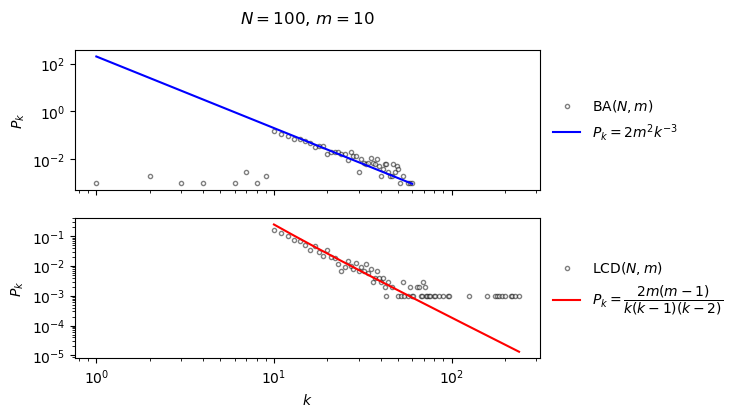

```python
N, m = 100, 10
trials = 10
fig, ax = plt.subplots(2, 1, sharex=True, figsize=(6, 4))

r = {} # records
for i, model in enumerate(['BA', 'LCD']):
    G = eval(model.lower())
    p = np.bincount([k for t in range(trials)
                     for n, k in G(N, m, 5056+t).degree])
    k = np.arange(np.argmax(p>0), len(p)).astype(float)
    r[model] = (k, p[int(k[0]):] / (N*trials))
    ax[i].loglog(*r[model], 'k.', mfc='w', alpha=.5,
                 label=r'$\mathrm{%s}(N,m)$'%model)

kBA, kLCD = r['BA'][0], r['LCD'][0]
ax[0].plot(kBA, 2*m**2*kBA**-3, 'b', label='$P_k=2m^2k^{-3}$')
ax[1].plot(kLCD, 2*m*(m-1)/kLCD/(kLCD-1)/(kLCD-2), 'r',
           label=r'$P_k=\dfrac{2m(m-1)}{k(k-1)(k-2)}$')
ax[0].set_title(r'$N=%d,\,m=%d$' % (N, m)+'\n')
ax[1].set_xlabel('$k$')
for a in ax:
    a.set_ylabel('$P_k$')
    a.legend(loc='center left', bbox_to_anchor=(1, .5), frameon=False)
```

### Degree dynamics.

We can calculate node $i$'s **expected** degree $k_i$ as a function of time $t$. Suppose $i$ is created at time $t_i$, its age is $a_i=t-t_i$ at time $t$. When it is created, it is given $c_i$ edges. For a BA network, nodes outside $G^{\left(0\right)}$ have $c_i=m$. For an LCD network, $t_i=i$ and $c_i\approx\left(1+\delta_{i0}\right)m$.

\begin{aligned} k_i{\left(t\right)} = c_i \left(\dfrac{t}{t_i}\right) ^ \frac{1}{2} \equiv c_i \left(\dfrac{t}{t-a_i}\right) ^ \frac{1}{2} \end{aligned}

The formula implies that an older node has a higher degree, and its growth rate

\begin{aligned} \dfrac{\mathrm{d}}{\mathrm{d}t}k_i \sim \dfrac{1}{{\sqrt{t_i t}}} \end{aligned}

implies that not only does an older node possess a higher degree but also its degree grows faster than a younger node's.

Interestingly, if a network shows $k_i\sim\left(\dfrac{t}{t_i}\right)^\beta$ for some $\beta$, its degree exponent turns out to read $\gamma=\dfrac{1}{\beta}+1$. For the LCD network, $\beta=\dfrac12$ indeed yields $\gamma=3$.

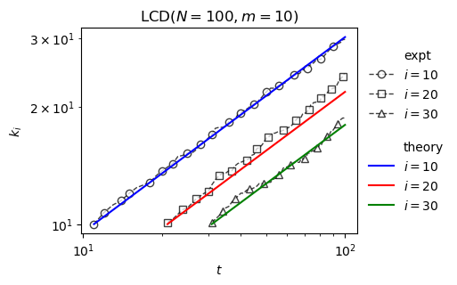

```python
N, m = 100, 10
trials = 10
k = sum(lcd(N, m, 5056+t, True)[1] for t in range(trials))/trials

plt.figure(figsize=(4, 3))
plt.plot([], [], 'w.', label='expt')
for i, marker in zip([10, 20, 30], ['o', 's', '^']):
    t = np.arange(i+1, N+1)
    plt.loglog(t, k[i:,i], marker+'k--', lw=1, mfc='w',
               markevery=.05, alpha=.75, label='$i=%d$'%i)
plt.plot([], [], 'w.', label='\ntheory')
for i, c in zip([10, 20, 30], ['b', 'r', 'g']):
    t = np.arange(i+1, N+1)
    plt.plot(t, (1+int(i==0))*m*(t/(i+1))**.5, c, label='$i=%d$'%i)
plt.legend(loc='center left', bbox_to_anchor=(1, .5), frameon=False)
plt.title(r'$\mathrm{LCD}\left(N=%d,m=%d\right)$'%(N, m))
plt.xlabel('$t$')
plt.ylabel('$k_i$')
plt.show()
```

### Clustering coefficient.

The average clustering coefficient of a BA network with $m>1$ follows ([Klemm and Eguluz, 2002](https://journals.aps.org/pre/abstract/10.1103/PhysRevE.65.036123))

\begin{aligned} C \sim \dfrac{\ln^2 {N}}{N}\,. \end{aligned}

(A BA network with $m=1$ is merely a tree.) If $N\gg m>1$, it becomes

\begin{aligned} C= \dfrac{m}{4}\dfrac{\ln^2{N}}{N}\,. \end{aligned}

On one hand, a BA network is more clustered than a comparable (i.e. similarly large and similarly dense) ER network, which shows $C\sim\dfrac{1}{N}$. On the other hand, it is much less clustered than a comparable WS network and comparable real-world networks, whose $C$ barely decreases with $N$.

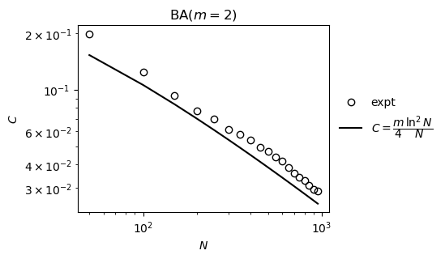

```python
m = 2
trials = 10
Ns = np.arange(0, 1000, 50)[1:]
Cs = [sum(nx.average_clustering(ba(N, m, 5056+t))
          for t in range(trials))/trials for N in Ns]

plt.figure(figsize=(4, 3))
plt.loglog(Ns, Cs, 'ko', mfc='none', label='expt')
plt.plot(Ns, m/4*np.log(Ns)**2/Ns, 'k',
         label=r'$C=\dfrac{m}{4}\dfrac{\ln^2{N}}{N}$')
plt.legend(loc='center left', bbox_to_anchor=(1, .5), frameon=False)
plt.title(r'$\mathrm{BA}\left(m=2\right)$')
plt.xlabel('$N$')
plt.ylabel('$C$')
plt.show()
```

### Shortest path length.

The average shortest path length of a BA network follows ([Bollobás and Riordan, 2004](https://link.springer.com/article/10.1007/s00493-004-0002-2); [Cohen and Havlin, 2003](https://journals.aps.org/prl/abstract/10.1103/PhysRevLett.90.058701))

\begin{aligned} L \sim \dfrac{\ln{N}}{\ln{\ln{N}}}\,, \end{aligned}

which is generally true for any scale-free network with a degree exponent $\gamma=3$. As Section 1 mentions, this length is shorter than $\ln{N}$ and marks the presence of an **ultra-small world**.

However, it holds only if $N\rightarrow\infty$, otherwise the BA network sort of "expands" and gives $L\sim\ln{N}$ instead.

## 2.3 Generalizations

Here are two interesting generalizations of the Barabási-Albert model.

### The Bianconi-Barabási model.

The Bianconi-Barabási (BB) model amends the edge probability in the BA model to

\begin{aligned} p_{ij} = \dfrac{\eta_jk_j}{\sum_h \eta_hk_h}\,, \end{aligned}

where $\eta$ measures a node's "fitness" (like a person's wealth or a paper's number of citations). The BB model reduces to the BA model if all nodes have the same fitness $\eta=1$.

Bianconi and Barabási particularly studied the case in which $\eta$ follows a distribution $f{\left(\eta\right)}\sim(1-\eta)^\xi$ for $\xi>0$. If $\xi$ is large, there are many strong nodes and many weak nodes but few normal nodes. Consequently, once $\xi$ is larger than some critical value, a BB network possesses a bizarre degree distribution:

\begin{aligned} P_k = \begin{cases} \text{very high} & \left(k\rightarrow0\right) \\ \text{a finite number} & \left(k\rightarrow\infty\right) \\ 0 & \left(k\text{ in between}\right) \end{cases}\,. \end{aligned}

It means that the network **has lost the scale-free topology but resembles a star**. In Bianconi and Barabási's terms, while a scale-free topology emerges because **the rich get richer**, a star-like topology emerges because **the winner takes all**.

### Non-linear preferential attachment.

The BA model features linear preferential attachment by defining $p_{ij}\sim k_j$. In fact, we may replace it with $p_{ij}\sim k_j^\alpha$, and the size of $\alpha$ defines four regimes.

- **Constant regime $\alpha=0$.** All edges are equally possible, so the resultant network is simply a random network. Its maximum degree grows logarithmically.

\begin{aligned}k_\text{max} \sim \ln{t}\end{aligned}

- **Sublinear regime $0<\alpha<1$.** The resultant network also looks random but contains a few hubs, so it has a higher maximum degree than the constant regime.

\begin{aligned}k_\text{max} \sim \left(\ln{t}\right)^\frac{1}{1-\alpha}\end{aligned}

- **Linear regime $\alpha=1$.** The resultant network is an ordinary scale-free BA network, and its maximum degree follows a power law.

\begin{aligned}k_\text{max} \sim t^\frac{1}{\gamma-1}\end{aligned}

- **Superlinear regime $\alpha>1$**. The resultant network resembles a star, and its maximum degree grows linearly.

\begin{aligned}k_\text{max} \sim t\end{aligned}

## 2.4 Origins of preferential attachment

Although Barábasi and Albert successfully explained the scale-free property with preferential attachment (i.e. $p_{ij}\sim k_j$), why would real networks succumb to this rule during evolution? There are two philosophically competing schools of thought on the answer.

### Randomness.

On one hand, some people suggest that preferential attachment is a by-product of random processes and just naturally exists

- if every new node links to an endpoint of an arbitrary edge, OR
- if every new node links to an arbitrary node with probability $p$ or any one of the node's neighbours with probability $1-p$.

### Optimization.

On the other hand, some people suggest that preferential attachment is the result of some intelligent processes. They assume that a network has an intrinsic centre (i.e. the most important node), so every new node tries to form links to minimize its distance to the centre.

Although their logic sounds totally opposite, both schools can reproduce the phenomenon of preferential attachment with models that do not explicitly define the edge probability $p_{ij}$.

# References

1. Barabási A.-L. (2016) *Network Science* (Cambridge University Press, Cambridge).
2. Barabási A.-L. and Albert R. (1999) *Emergence of Scaling in Random Networks*, Science **286**, 509.
3. Bollobás B., Riordan O., Spencer J., and Tusnády G. (2001) *The degree sequence of a scale-free random graph process*, Random Structures and Algorithms **18**, 279.
4. Bollobás, B. and Riordan O. (2004) *The Diameter of a Scale-Free Random Graph*, Combinatorica, **24**, 5.
5. Clauset A., Shalizi C. R., and Newman M. E. J. (2009) *Power-Law Distributions in Empirical Data*, SIAM Review **51**, 661.
6. Cohen R. and Havlin S. (2003) *Scale-Free Networks Are Ultrasmall*, Phys. Rev. Lett. **90**, 058701.
7. Klemm K. and Eguluz V. M. (2002) *Highly clustered scale-free networks*, Phys. Rev. E **65**, 057102.
8. Newman M. E. J. (2001) *The structure of scientific collaboration networks*, Proc. Natl. Acad. Sci. USA **98**, 404.